# PRACTICA 2: LIMPIEZA Y VALIDACIÓN DE LOS DATOS

7 de junio 2021

# 1. Descripción del dataset.

El dataset sobre el cual vamos a realizar el analisis se ha extaído a partir de este enlace en Kaggle:

https://www.kaggle.com/dhruvildave/top-play-store-games?select=android-games.csv

Está constituido por 15 variable (columnas) y 1730 (filas o registros).

El dataset que hemos seleccionado contiene datos de los 100 juegos de Google Play Store mejor valorados. Las variables que recoge el dataset son:

- Rank: Calsificación de una categoría particular.
- Title: Nombre del juego.
- Total ranting: Número total de calificaciones.
- Installs: Número de instalaciones aproximado.
- Average rating: Promedio de estrellas.
- growth (30 days): Porcentaje de crecimiento en 30 días.
- growth (60 days): Porcentaje de crecimiento en 60 días.
- price: Precio en Dólares.
- category: Categoría del juego.
- X5.star.ratings: Número de calificaciones de 5 estrellas.
- X4.star.ratings: Número de calificaciones de 4 estrellas.
- X3.star.ratings: Número de calificaciones de 3 estrellas.
- X2.star.ratings: Número de calificaciones de 2 estrellas.
- X1.star.ratings: Número de calificaciones de 1 estrellas.
- paid: Toma valor verdadero si se pago y falso si no se hizo.

### 1.1 ¿Por qué es importante y qué pregunta/problema pretende responder?

Una vez que conocemos las variables que componen el dataset, pasamos a definir cuál es la pregunta que tratamos de resolver y por qué es importante este dastaset.

Como bien sabemos el mundo de los videojuegos ha cambiado completamente en la última década, es decir, antes solo se podía jugar a través de consolas “fijas” como la Nintendo 64, la PlayStation… Posteriormente aparecieron las consolas portátiles, algunas de las más importantes fueron la Game Boy, la PlayStationg Portable…

Desde que apareció el primer videojuego en 1958 con el conocido “Tennis for two” de William Higinbotham y Robert Dvorak, la tendencia era la misma en cuanto al desarrollo de los juegos, el cómo venderlos, cómo hacer que llegaran a más gente, cómo de buenos eran…

El tiempo avanzaba y parecía que esta industria seguía igual, sin embargo hubo un hecho importante, la aparición de los smartphones. Esta nueva herramienta ha cambiado en todos los aspectos como se rige el mundo, lo que supone también un cambio en la industria de los videojuegos, es decir, ahora la gran mayaría del público gamer juega más en dispositivos móviles que en las consolas tradicionales.

Al tener mayor audiencia aumenta la oferta, por lo que analizar este dataset nos puede aportar mucha información, por ejemplo el saber qué tipo de juego va a tener más éxito, si se decide poner un precio al juego y de ser así cuál, qué categoría de juego tiene un mayor público…

Como podemos observar este dataset nos puede proporcionar mucha información en varios aspectos, pero en nuestro caso vamos a analizar exclusivamente el rank, es decir, vamos a descubrir de qué depende que un juego tenga un ranking mayor o en otras palabras, cuánto éxito puede tener. Para ello además de analizar qué variables están correlacionadas, vamos a realizar un contraste de hipótesis para saber si el número de instalaciones afecta al ranking, y crearemos diferentes modelos para predecir el ranking que puede llegar a tener un juego dependiendo de sus características…

La respuesta a la pregunta que nos hemos planteado se resolverá a lo largo de la práctica, pero lo primero de todo es hacer la limpieza del dataset.

# 2. Integración y selección de los datos de interés a analizar.

## 2.1. Integración de los datos.

En primer lugar, realizamos la carga del fichero que contiene los datos para nuestro análisis en formato csv, el cual está delimitado por comas y los decimales “·”. Obtenemos como resultado de la llamada a la función read.csv() será un objeto data.frame.

```r
# read data
games <- read.csv("../data/android-games.csv", header=TRUE, sep=",",
                  na.strings="NA", dec=".", strip.white=TRUE)

n.var <- names(games)

#View(games)
```

Mostramos las primeras líneas del dataset, así como su encabezado.

```r
head(games)
```

```
##   rank                                        title total.ratings installs
## 1    1                 Garena Free Fire - The Cobra      80678661  500.0 M
## 2    2                  PUBG MOBILE: Graffiti Prank      35971961  100.0 M
## 3    3                    Mobile Legends: Bang Bang      25836869  100.0 M
## 4    4                                  Brawl Stars      17181659  100.0 M
## 5    5 Sniper 3D: Fun Free Online FPS Shooting Game      14237554  100.0 M
## 6    6                               Shadow Fight 2      14048931  100.0 M
##   average.rating growth..30.days. growth..60.days. price    category
## 1           4.33              2.9              7.9     0 GAME ACTION
## 2           4.24              2.0              3.1     0 GAME ACTION
## 3           4.08              1.6              3.3     0 GAME ACTION
## 4           4.27              4.1              6.6     0 GAME ACTION
## 5           4.33              0.8              1.8     0 GAME ACTION
## 6           4.57              0.6              1.5     0 GAME ACTION
##   X5.star.ratings X4.star.ratings X3.star.ratings X2.star.ratings
## 1        61935712         4478738         2795172         1814999
## 2        26670566         2109631         1352610          893674
## 3        17850942         1796761         1066095          725429
## 4        12493668         1474319          741410          383478
## 5         9657878         2124544         1034025          375159
## 6        11532143          961926          448184          217044
##   X1.star.ratings  paid
## 1         9654037 False
## 2         4945478 False
## 3         4397640 False
## 4         2088781 False
## 5         1045945 False
## 6          889631 False
```

Una vez cargados los datos comprobamos que nuestro fichero contiene 1730 registros y 15 variables.

Las variables son de tipo rank, title, total.ratings, installs, average.rating, growth..30.days., growth..60.days., price, category, X5.star.ratings, X4.star.ratings, X3.star.ratings, X2.star.ratings, X1.star.ratings, paid.

Como podemos en el resumen de los estadísticos descriptivos de las distintas variables no hay ningún campo no informado.

```r
summary(games)
```

```
##       rank           title           total.ratings        installs
##  Min.   :  1.00   Length:1730        Min.   :   38238   Length:1730
##  1st Qu.: 25.00   Class :character   1st Qu.:  187999   Class :character
##  Median : 51.00   Mode  :character   Median :  457675   Mode  :character
##  Mean   : 50.48                      Mean   : 1101182
##  3rd Qu.: 75.75                      3rd Qu.:  944334
##  Max.   :100.00                      Max.   :80678661
##  average.rating  growth..30.days.   growth..60.days.      price
##  Min.   :3.090   Min.   :     0.0   Min.   :  0.000   Min.   :0.00000
##  1st Qu.:4.180   1st Qu.:     0.1   1st Qu.:  0.300   1st Qu.:0.00000
##  Median :4.330   Median :     0.5   Median :  1.000   Median :0.00000
##  Mean   :4.313   Mean   :   193.2   Mean   :  3.969   Mean   :0.01297
##  3rd Qu.:4.490   3rd Qu.:     1.6   3rd Qu.:  3.300   3rd Qu.:0.00000
##  Max.   :4.910   Max.   :140394.4   Max.   :605.100   Max.   :7.49000
##    category         X5.star.ratings    X4.star.ratings   X3.star.ratings
##  Length:1730        Min.   :   21898   Min.   :   2441   Min.   :    707
##  Class :character   1st Qu.:  135829   1st Qu.:  21802   1st Qu.:  10278
##  Mode  :character   Median :  310944   Median :  54644   Median :  26658
##                     Mean   :  788384   Mean   : 121647   Mean   :  59550
##                     3rd Qu.:  651131   3rd Qu.: 109565   3rd Qu.:  55818
##                     Max.   :61935712   Max.   :5397273   Max.   :2795172
##  X2.star.ratings   X1.star.ratings       paid
##  Min.   :    288   Min.   :    527   Length:1730
##  1st Qu.:   4530   1st Qu.:  13561   Class :character
##  Median :  11330   Median :  35694   Mode  :character
##  Mean   :  27962   Mean   : 103636
##  3rd Qu.:  25266   3rd Qu.:  86326
##  Max.   :1814999   Max.   :9654037
```

### 2.2. Tipo variables.

Comprobamos de que tipo es cada variable.

```r
#read data
res <- sapply(games,  class)
kable(data.frame(variables=names(res),clase=as.vector(res)))
```

| variables | clase |
| --- | --- |
| rank | integer |
| title | character |
| total.ratings | integer |
| installs | character |
| average.rating | numeric |
| growth..30.days. | numeric |
| growth..60.days. | numeric |
| price | numeric |
| category | character |
| X5.star.ratings | integer |
| X4.star.ratings | integer |
| X3.star.ratings | integer |
| X2.star.ratings | integer |
| X1.star.ratings | integer |
| paid | character |

A continuación analizamos en mayor profundidad los distintos valores que toman las variables categóricas.

```r
title <-unique(games$title)
head(title)
```

```
## [1] "Garena Free Fire - The Cobra"
## [2] "PUBG MOBILE: Graffiti Prank"
## [3] "Mobile Legends: Bang Bang"
## [4] "Brawl Stars"
## [5] "Sniper 3D: Fun Free Online FPS Shooting Game"
## [6] "Shadow Fight 2"
```

```r
unique(games$category)
```

```
##  [1] "GAME ACTION"       "GAME ADVENTURE"    "GAME ARCADE"
##  [4] "GAME BOARD"        "GAME CARD"         "GAME CASINO"
##  [7] "GAME CASUAL"       "GAME EDUCATIONAL"  "GAME MUSIC"
## [10] "GAME PUZZLE"       "GAME RACING"       "GAME ROLE PLAYING"
## [13] "GAME SIMULATION"   "GAME SPORTS"       "GAME STRATEGY"
## [16] "GAME TRIVIA"       "GAME WORD"
```

```r
unique(games$installs)
```

```
## [1] "500.0 M"  "100.0 M"  "50.0 M"   "10.0 M"   "5.0 M"    "1.0 M"    "1000.0 M"
## [8] "500.0 k"  "100.0 k"
```

```r
unique(games$paid)
```

```
## [1] "False" "True"
```

Observamos que la variable title toma un valor distinto para cada registro. Más adelante trataremos el resto de variables que sean necesarias para nuestro análisis.

## 2.3. Selección de variables.

Para nuestro análisis vamos a eliminar del dataset los campos calculados, en nuestro caso son la media de estrellas que es la variable **average.rating, paid** y **total.ratings**. Por otro lado, para nuestro análisis es suficiente con uno de los porcentajes de crecimiento por tanto eliminamos también la variable **growth..60.days**. El resto de variables consideramos que son necesarias para el objetivo de nuestro análisis, ver como influyen en el ranking de un video juego.

```r
games <-games[,c(-3,-5,-7,-15)] # Eliminamos las variables en cuestión.

head(games)
```

```
##   rank                                        title installs growth..30.days.
## 1    1                 Garena Free Fire - The Cobra  500.0 M              2.9
## 2    2                  PUBG MOBILE: Graffiti Prank  100.0 M              2.0
## 3    3                    Mobile Legends: Bang Bang  100.0 M              1.6
## 4    4                                  Brawl Stars  100.0 M              4.1
## 5    5 Sniper 3D: Fun Free Online FPS Shooting Game  100.0 M              0.8
## 6    6                               Shadow Fight 2  100.0 M              0.6
##   price    category X5.star.ratings X4.star.ratings X3.star.ratings
## 1     0 GAME ACTION        61935712         4478738         2795172
## 2     0 GAME ACTION        26670566         2109631         1352610
## 3     0 GAME ACTION        17850942         1796761         1066095
## 4     0 GAME ACTION        12493668         1474319          741410
## 5     0 GAME ACTION         9657878         2124544         1034025
## 6     0 GAME ACTION        11532143          961926          448184
##   X2.star.ratings X1.star.ratings
## 1         1814999         9654037
## 2          893674         4945478
## 3          725429         4397640
## 4          383478         2088781
## 5          375159         1045945
## 6          217044          889631
```

# 3. Limpieza de los datos.

Con el archivo de datos obtenido del proceso anterior, vemos la necesidad, para seguir con nuestro análisis, de factorizar la variable **Category** y reconvertir a numérica la variable **Installs**.

A continuación, damos un valor numérico del 1 al 17 a los valores que toma la variable **Category**.

```r
levels <- c(unique(games$category))
games$category_num <- match(games$category, levels)
games$category_factor = factor(games$category, levels = levels)
games$category_num2 <- as.integer(games$category_factor)

head(games)
```

```
##   rank                                        title installs growth..30.days.
## 1    1                 Garena Free Fire - The Cobra  500.0 M              2.9
## 2    2                  PUBG MOBILE: Graffiti Prank  100.0 M              2.0
## 3    3                    Mobile Legends: Bang Bang  100.0 M              1.6
## 4    4                                  Brawl Stars  100.0 M              4.1
## 5    5 Sniper 3D: Fun Free Online FPS Shooting Game  100.0 M              0.8
## 6    6                               Shadow Fight 2  100.0 M              0.6
##   price    category X5.star.ratings X4.star.ratings X3.star.ratings
## 1     0 GAME ACTION        61935712         4478738         2795172
## 2     0 GAME ACTION        26670566         2109631         1352610
## 3     0 GAME ACTION        17850942         1796761         1066095
## 4     0 GAME ACTION        12493668         1474319          741410
## 5     0 GAME ACTION         9657878         2124544         1034025
## 6     0 GAME ACTION        11532143          961926          448184
##   X2.star.ratings X1.star.ratings category_num category_factor category_num2
## 1         1814999         9654037            1     GAME ACTION             1
## 2          893674         4945478            1     GAME ACTION             1
## 3          725429         4397640            1     GAME ACTION             1
## 4          383478         2088781            1     GAME ACTION             1
## 5          375159         1045945            1     GAME ACTION             1
## 6          217044          889631            1     GAME ACTION             1
```

En el caso de la variable **Install** hemos supuesto que M millones y que k son miles, por lo que hemos multiplicado la M por 10^6 y k por 10^3.

```r
converter<-function(valueToConvert) {
   intValue <- 0
   intValue <- strtoi(substr(valueToConvert, 1, regexpr('\\.', valueToConvert)-1))
    if (grepl("M", valueToConvert, ignore.case = TRUE)) {
        intValue <- intValue * (10**6)
    }
    if (grepl("K", valueToConvert, ignore.case = TRUE)) {
       intValue <- intValue * (10**3)
    }
   intValue
}
games$int_installs <- sapply(games$installs, FUN=converter)
head(games)
```

```
##   rank                                        title installs growth..30.days.
## 1    1                 Garena Free Fire - The Cobra  500.0 M              2.9
## 2    2                  PUBG MOBILE: Graffiti Prank  100.0 M              2.0
## 3    3                    Mobile Legends: Bang Bang  100.0 M              1.6
## 4    4                                  Brawl Stars  100.0 M              4.1
## 5    5 Sniper 3D: Fun Free Online FPS Shooting Game  100.0 M              0.8
## 6    6                               Shadow Fight 2  100.0 M              0.6
##   price    category X5.star.ratings X4.star.ratings X3.star.ratings
## 1     0 GAME ACTION        61935712         4478738         2795172
## 2     0 GAME ACTION        26670566         2109631         1352610
## 3     0 GAME ACTION        17850942         1796761         1066095
## 4     0 GAME ACTION        12493668         1474319          741410
## 5     0 GAME ACTION         9657878         2124544         1034025
## 6     0 GAME ACTION        11532143          961926          448184
##   X2.star.ratings X1.star.ratings category_num category_factor category_num2
## 1         1814999         9654037            1     GAME ACTION             1
## 2          893674         4945478            1     GAME ACTION             1
## 3          725429         4397640            1     GAME ACTION             1
## 4          383478         2088781            1     GAME ACTION             1
## 5          375159         1045945            1     GAME ACTION             1
## 6          217044          889631            1     GAME ACTION             1
##   int_installs
## 1        5e+08
## 2        1e+08
## 3        1e+08
## 4        1e+08
## 5        1e+08
## 6        1e+08
```

Seleccionamos las variables con las que vamos a hacer nuestro análisis.

```r
games <-games[,c(-3,-6,-12,-13)] # Eliminamos las variables en variables que sobran
```

Finalmente, tras tratar las variables mal informadas nos queda nuestro dataset final sobre el que vamos aplicar la limpieza de datos y posteriormente el análisis.

```r
#read data
res <- sapply(games,  class)
kable(data.frame(variables=names(res),clase=as.vector(res)))
```

| variables | clase |
| --- | --- |
| rank | integer |
| title | character |
| growth..30.days. | numeric |
| price | numeric |
| X5.star.ratings | integer |
| X4.star.ratings | integer |
| X3.star.ratings | integer |
| X2.star.ratings | integer |
| X1.star.ratings | integer |
| category_num2 | integer |
| int_installs | numeric |

Como podemos ver solo nos hemos quedado con una variable categóricas **Title**y el resto las hemos reconvertido en numéricas.

## 3.1. ¿Los datos contienen ceros o elementos vacíos? ¿Cómo gestionarías cada uno de estos casos?

Como se puede comprobar en el resumen de los estadisticos descriptivos de las distintas variables, no hay ningún valor nulo.

```r
summary(games)
```

```
##       rank           title           growth..30.days.       price
##  Min.   :  1.00   Length:1730        Min.   :     0.0   Min.   :0.00000
##  1st Qu.: 25.00   Class :character   1st Qu.:     0.1   1st Qu.:0.00000
##  Median : 51.00   Mode  :character   Median :     0.5   Median :0.00000
##  Mean   : 50.48                      Mean   :   193.2   Mean   :0.01297
##  3rd Qu.: 75.75                      3rd Qu.:     1.6   3rd Qu.:0.00000
##  Max.   :100.00                      Max.   :140394.4   Max.   :7.49000
##  X5.star.ratings    X4.star.ratings   X3.star.ratings   X2.star.ratings
##  Min.   :   21898   Min.   :   2441   Min.   :    707   Min.   :    288
##  1st Qu.:  135829   1st Qu.:  21802   1st Qu.:  10278   1st Qu.:   4530
##  Median :  310944   Median :  54644   Median :  26658   Median :  11330
##  Mean   :  788384   Mean   : 121647   Mean   :  59550   Mean   :  27962
##  3rd Qu.:  651131   3rd Qu.: 109565   3rd Qu.:  55818   3rd Qu.:  25266
##  Max.   :61935712   Max.   :5397273   Max.   :2795172   Max.   :1814999
##  X1.star.ratings   category_num2     int_installs
##  Min.   :    527   Min.   : 1.000   Min.   :1.000e+05
##  1st Qu.:  13561   1st Qu.: 5.000   1st Qu.:5.000e+06
##  Median :  35694   Median : 9.000   Median :1.000e+07
##  Mean   : 103636   Mean   : 8.975   Mean   :2.889e+07
##  3rd Qu.:  86326   3rd Qu.:13.000   3rd Qu.:5.000e+07
##  Max.   :9654037   Max.   :17.000   Max.   :1.000e+09
```

Con la función summary vemos si existen valores nulos y cual es el valor máximo y mínimo que toma cada variable. La variable price toma valor cero pero es de interés para el análisis ya que significa que el usuario no ha pagando nada. Por otro lado, la variable growth..30.days. también toma valor 0 en el caso de no haber crecimiento.

## 3.2. Identificación y tratamiento de valores extremos.

Los valores extremos o outliers son aquellos que parecen no ser congruentes sin los comparamos con el resto de los datos. Para identificarlos, podemos hacer uso de dos vías: (1) representar un diagrama de caja por cada variable y ver qué valores distan mucho del rango intercuartílico (la caja) o (2) utilizar la función boxplots.stats() de R, la cual se emplea a continuación. Así, se mostrarán sólo los valores atípicos para aquellas variables que los contienen:

```r
boxplot.stats(games$rank)$out
```

```
## integer(0)
```

```r
boxplot.stats(games$int_installs)$out
```

```
##  [1] 5e+08 5e+08 1e+09 5e+08 5e+08 1e+09 5e+08 5e+08 5e+08 5e+08 5e+08 5e+08
```

```r
out_growth <- boxplot.stats(games$growth..30.days.)$out
head(out_growth)
```

```
## [1]      4.1      6.3      6.1   4560.2   1164.8 139410.4
```

```r
boxplot.stats(games$price)$out
```

```
## [1] 0.99 4.99 7.49 1.99 2.99 1.99 1.99
```

```r
out_X5 <- boxplot.stats(games$X5.star.ratings)$out
head(out_X5)
```

```
## [1] 61935712 26670566 17850942 12493668  9657878 11532143
```

```r
out_X4 <- boxplot.stats(games$X4.star.ratings)$out
head(out_X4)
```

```
## [1] 4478738 2109631 1796761 1474319 2124544  961926
```

```r
out_X3 <- boxplot.stats(games$X3.star.ratings)$out
head(out_X3)
```

```
## [1] 2795172 1352610 1066095  741410 1034025  448184
```

```r
out_X2 <- boxplot.stats(games$X2.star.ratings)$out
head(out_X2)
```

```
## [1] 1814999  893674  725429  383478  375159  217044
```

```r
out_X1 <- boxplot.stats(games$X1.star.ratings)$out
head(out_X1)
```

```
## [1] 9654037 4945478 4397640 2088781 1045945  889631
```

Vemos una representación gráfica con boxplot de las variables numéricas para comprobar si existen valores extremos.

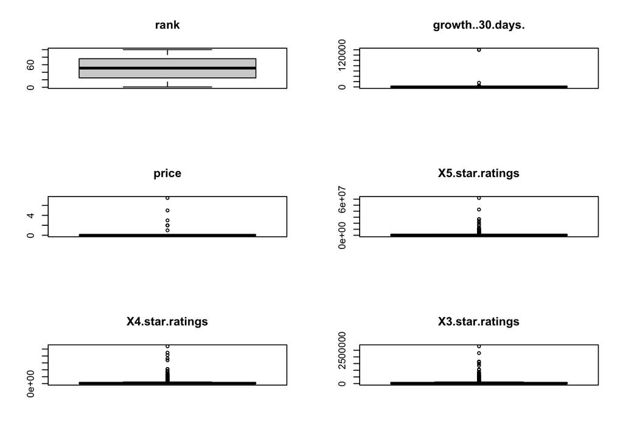

```r
par(mfrow=c(3,2))
for(i in 1:ncol(games)) {
  if (is.numeric(games[,i])){
    boxplot(games[,i], main = colnames(games)[i], width = 100)
  }
}
```

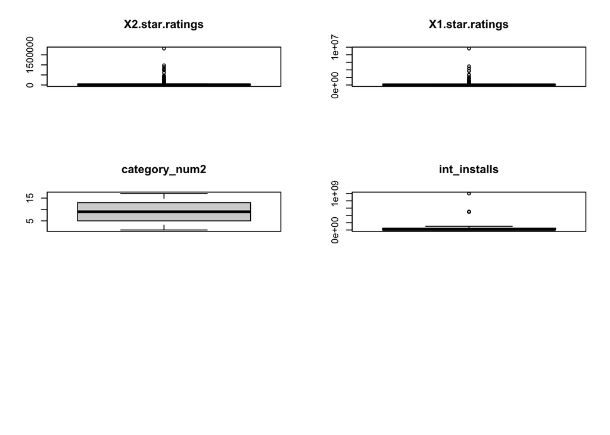

```r
par(mfrow=c(1,1))
```

Se considera valores extremos a aquellos valores cuando se encuentra alejado 3 desviaciones estándar con respecto a la media. Por ello, en muchos trabajos se utiliza la representación de los datos mediante gráficos de cajas (boxplots), con el objetivo de detectar dichos outliers.

Las variables que si es posible que sean erróneos porque con fines mal intencionados se puede haber añadido excesivas valoraciones a un juego por medios automáticos (Robot) de forma que se pueden haber valores extremos estas son: - growth..30.days. - X5.star.ratings  
- X4.star.ratings  
- X3.star.ratings - X2.star.ratings  
- X1.star.ratings

Es por ello, que hemos decidido eliminar estos valores.

```r
filas_old <-nrow(games)
games <- games[-which(games$growth..30.days. %in% out_growth),]
games <- games[-which(games$X5.star.ratings %in% out_X5),]
games <- games[-which(games$X4.star.ratings %in% out_X4),]
games <- games[-which(games$X3.star.ratings %in% out_X3),]
games <- games[-which(games$X2.star.ratings %in% out_X2),]
newgames <- games[-which(games$X1.star.ratings %in% out_X1),]
filas_new <-nrow(newgames)
```

Una vez eliminados los outlier, comprobamos gráficamente como se distribuyen los datos de estas variables.

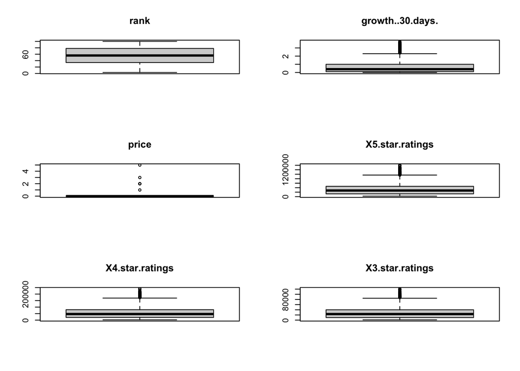

```r
par(mfrow=c(3,2))
for(i in 1:ncol(newgames)) {
  if (is.numeric(newgames[,i])){
    boxplot(newgames[,i], main = colnames(newgames)[i], width = 100)
  }
}
```

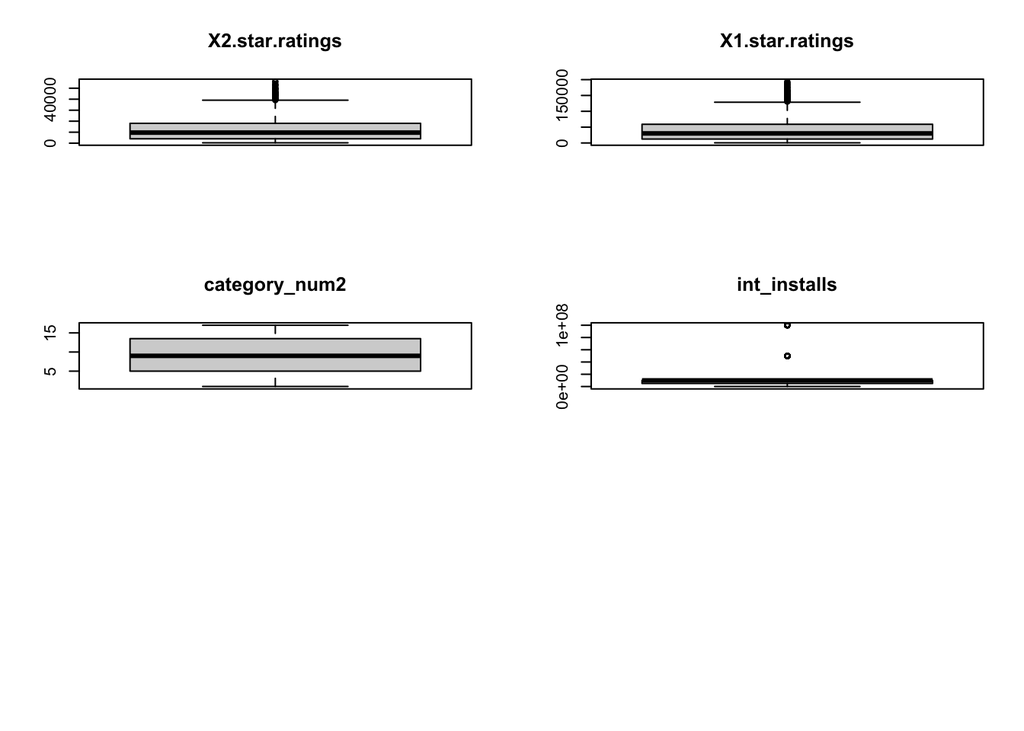

```r
par(mfrow=c(1,2))
```

Hemos pasado de 1730 filas a 1296 filas.

Por último, exportamos el nuevo dataset a un nuevo csv.

```r
my.newfile <- "../data/newgame.csv"
write.csv(newgames, file=my.newfile, row.names = FALSE)
```

# 4. Análisis de los datos.

## 4.1. Selección de los grupos de datos que se quieren analizar/comparar (planificación de los análisis a aplicar).

Antes de comenzar con el análisis en sí, vamos a seleccionar diferentes grupos que pueden ser interesantes a la hora de analizar o comparar. Cabe destacar que no todos los grupos se van usar, pero pueden ser de utilidad para estudios posteriores, es decir, en el dataset original la variable rank viene determinada para cada categoría (si la categoría es “SPORTS” rank toma valores del 1 al 100 para los juegos de tipo sport, si la categoría es “STRATEGY” rank vuelve a tomar valores entre 1 y 100 para los juegos de dicha categoría). Como el objetivo nuestro es analizar el ranking, éste solo tiene sentido analizarlo para cada categoría de juego, es por ello que las agrupaciones las vamos a hacer por categoría.

Por otro lado, vamos a crear un par de grupos más que nos van a servir para solventar la pregunta que nos hacemos en el contraste de hipótesis, la cual la detallaremos más adelante:

```r
# Juegos cuya categoría es GAME ACTION
newgames.action = newgames[newgames$category_num2 == 1,]

# Juegos cuya categoría es GAME ADVENTURE
newgames.adventure = newgames[newgames$category_num2 == 2,]

# Juegos cuya categoría es GAME ARCADE
newgames.arcade = newgames[newgames$category_num2 == 3,]

# Juegos cuya categoría es GAME BOARD
newgames.board = newgames[newgames$category_num2 == 4,]

# Juegos cuya categoría es GAME CARD
newgames.card = newgames[newgames$category_num2 == 5,]

# Juegos cuya categoría es GAME CASINO
newgames.casino = newgames[newgames$category_num2 == 6,]

# Juegos cuya categoría es GAME CASUAL
newgames.casual = newgames[newgames$category_num2 == 7,]

# Juegos cuya categoría es GAME EDUCATIONAL
newgames.educational = newgames[newgames$category_num2 == 8,]

# Juegos cuya categoría es GAME MUSIC
newgames.music = newgames[newgames$category_num2 == 9,]

# Juegos cuya categoría es GAME PUZZLE
newgames.puzzle = newgames[newgames$category_num2 == 10,]

# Juegos cuya categoría es GAME RACING
newgames.racing = newgames[newgames$category_num2 == 11,]

# Juegos cuya categoría es GAME ROLE PLAYING
newgames.role = newgames[newgames$category_num2 == 12,]

# Juegos cuya categoría es GAME SIMULATION
newgames.simulation = newgames[newgames$category_num2 == 13,]

# Juegos cuya categoría es GAME SPORTS
newgames.sports = newgames[newgames$category_num2 == 14,]

# Juegos cuya categoría es GAME STRATEGY
newgames.strategy = newgames[newgames$category_num2 == 15,]

# Juegos cuya categoría es GAME TRIVIA
newgames.trivia = newgames[newgames$category_num2 == 16,]

# Juegos cuya categoría es GAME WORD
newgames.word = newgames[newgames$category_num2 == 17,]

# Juegos cuya categoría es GAME WORD y tiene un número de instalaciones bajas
newgames.ins_low = newgames.word[newgames.word$int_installs < 10000000,]

# Juegos cuya categoría es GAME WORD y tiene un número de instalaciones bajas
newgames.ins_high = newgames.word[newgames.word$int_installs >= 10000000,]
```

## 4.2. Comprobación de la normalidad y homogeneidad de la varianza.

Una vez que tenemos los grupos que queremos analizar/comparar vamos a comprobar la normalidad y homogeneidad de la varianza.

Dado que el objetivo de esta práctica es demostrar el conocimiento adquirido y no hacer un estudio completo, vamos a realizar el análisis de los datos a partir de un grupo definido en el apartado anterior, en nuestro caso hemos elegido la categoría “GAME WORD”, por lo que vamos a hacer uso del dataframe newgames.word. El estudio que vamos a realizar para esta categoría se podría hacer para todas las demás y así tener un análisis completo del mercado para cada categoría.

Una vez hecha esta aclaración realizamos la **comprobación de la normalidad**, para ello hacemos uso de una librería externa y poder aplicar sobre las variables cuantitativas el test de Anderson-Darling.

Partimos de la base que la hipótesis nula es que la variable sigue una distribución normal, y la hipótesis alternativa que no sigue dicha distribución, por lo tanto vamos a comprobar para cada variable si el pvalor obtenido es menor que el nivel de significancia, es decir, si pvalor < alfa, de ser así podemos rechazar la hipótesis nula a favor de la alternativa.

Definimos la función que nos realiza este cálculo:

```r
test_normalidad = function(df, alpha = 0.05) {
  # Inicializamos
  var_no_dist_normal = c()
  var_dist_normal = c()
  cols_eliminar = c()
  col_names = colnames(df)

  # Comprobamos que las variables tengan más de un valor único,
  # ya que de lo contrario no funciona ad.test
  for (i in 1:ncol(df)) {
     if (is.numeric(df[, i]) | is.integer(df[, i])) {
       if (length(unique(df[, i])) == 1)
          cols_eliminar[length(cols_eliminar) + 1] = col_names[i]
     }
  }

  # Eliminamos dichas variables
  df = df[, !(names(df) %in% cols_eliminar)]

  # Añadimos dichas variables a la lista de variables que no siguen
  # una distribución normal
  for (i in 1:length(cols_eliminar)) {
    var_no_dist_normal[i] = cols_eliminar[i]
  }

  # Comprobamos para cada columna si sigue una distribución normal o no
  col_names = colnames(df)
  for (i in 1:ncol(df)) {

    if (is.numeric(df[, i]) | is.integer(df[, i])) {
      pvalue = ad.test(df[, i])$p.value

      # No proviene de una distribución normal
      if (pvalue < alpha) {
        var_no_dist_normal[length(var_no_dist_normal) + 1] = col_names[i]
      } else {
        var_dist_normal[length(var_dist_normal) + 1] = col_names[i]
      }
    }
  }

  # Imprimimos por pantalla los resultado
  cat("Variables que NO siguen una distribución normal: \n\n")
  for (c in var_no_dist_normal) {
    cat(c, "\n")
  }
  cat("\n------------------------------\n\n")
  cat("Variables que SÍ siguen una distribución normal: \n\n")
  for (c in var_dist_normal) {
    cat(c, " ")
  }
}
```

Una vez que hemos definido la función la llamamos para obtener los resultados:

```r
test_normalidad(newgames.word, alpha = 0.05)
```

```
## Variables que NO siguen una distribución normal:
##
## price
## category_num2
## rank
## growth..30.days.
## X5.star.ratings
## X4.star.ratings
## X3.star.ratings
## X2.star.ratings
## X1.star.ratings
## int_installs
##
## ------------------------------
##
## Variables que SÍ siguen una distribución normal:
```

De la anterior ejecución vemos que para la categoría “GAME WORD”, todas las variables cuantitativas no siguen una distribución normal.

Para concluir con este apartado realizamos el estudio de la homogeneidad de la varianza. En este caso la hipótesis nula es que las varianzas son iguales y la alternativa en caso contrario. Si el pvalor es menor que alfa rechazamos la hipótesis nula a favor de la alternativa.

**El análisis de la homogeneidad** lo vamos a realizar con el fin de saber qué estadístico tenemos que aplicar para el contraste de hipótesis, por lo que vamos a tener cuenta las muestras de el ranking de un juego cuya categoría sea “GAME WORD” y con descargas altas, por otro lado el ranking de un juego cuya categoría sea “GAME WORD” y con descargas bajas, para ello utilizaremos en contraste de hipótesis F de Fisher:

```r
var.test(newgames.ins_low$rank, newgames.ins_high$rank, conf.level = 0.95)
```

```
##
##  F test to compare two variances
##
## data:  newgames.ins_low$rank and newgames.ins_high$rank
## F = 0.93713, num df = 32, denom df = 59, p-value = 0.8599
## alternative hypothesis: true ratio of variances is not equal to 1
## 95 percent confidence interval:
##  0.5199913 1.7879880
## sample estimates:
## ratio of variances
##          0.9371329
```

Tal y como podemos apreciar en la anterior ejecución obtenemos un pvalor = 0.8599 > alfa = 0.05, como el pvalor es mayor que la alfa no podemos rechazar la hipótesis nula, por lo tanto las varianzas de ambas muestras son homogéneas con un nivel de significancia del 0.05.

## 4.3. Aplicación de pruebas estadísticas para comparar los grupos de datos.

### En función de los datos y el objetivo del estudio, aplicar pruebas de contraste de hipótesis, correlaciones, regresiones, etc. Aplicar al menos tres métodos de análisis diferentes.

#### 4.3.1 ¿Qué variables cuantitativas influyen más en el ranking?

En este apartado lo que vamos realizar es calcular la correlación que hay entre cada una de las variables cuantitativas respecto al ranking, pero si la variable cuantitativa solo toma un valor la eliminamos para calcular la correlación:

```r
correlacion = function(df) {

  cols_eliminar = c()
  col_names = colnames(df)

  # Comprobamos que las variables tengan más de un valor único,
  # ya que de lo contrario no funciona ad.test
  for (i in 1:ncol(df)) {
     if (is.numeric(df[, i]) | is.integer(df[, i])) {
       if (length(unique(df[, i])) == 1)
         cols_eliminar[length(cols_eliminar) + 1] = col_names[i]
     }
  }

  # Eliminamos dichas variables
  df = df[, !(names(df) %in% cols_eliminar)]

  col_names = colnames(df)

  cat("Correlación respecto al campo \"rank\"\n")
  for (i in 2:ncol(df)) { # Comenzamos en dos ya que la primera
                          #columna siempre es el ranking

    if (is.numeric(df[, i]) | is.integer(df[, i])) {
      value_corr = cor.test(df[, "rank"], df[, i])$estimate
      cat("\n", col_names[i], " ", value_corr)
    }
  }

  # for (i in 2:ncol(df)) {
  #   if (is.numeric(df[, i]) | is.integer(df[, i])) {
  #     chart.Correlation(data.frame(df[, "rank"], df[, i]))
  #   }
  # }

}
```

Una vez definida la función que nos devuelve la correlación de cada variable respecto al ranking, la llamamos:

```r
correlacion(newgames.word)
```

```
## Correlación respecto al campo "rank"
##
##  growth..30.days.   -0.04847737
##  X5.star.ratings   -0.780417
##  X4.star.ratings   -0.7402165
##  X3.star.ratings   -0.7782859
##  X2.star.ratings   -0.6481703
##  X1.star.ratings   -0.5782686
##  int_installs   -0.5234909
```

Como podemos apreciar, el crecimiento en los últimos 30 días está muy poco correlacionado con el rank. Sin embargo vemos que los ratings están altamente correlacionados de forma inversa, es decir, cuanto más pequeño sea el número del ranking (mejor juego es) más valoraciones tiene de 5, 4 y 3 estrellas, y a medida que el ranking aumenta (peor es el juego) menos valoraciones positivas recibe el mismo.

Otro aspecto a tener en cuenta es que cuanto mejor sea el juego (menor número en el rank) más descargas se producen del mismo.

Por lo tanto, vemos que estas variables influyen altamente en el ranking del juego.

Otra forma de calcular la correlación de forma más detallada junto con la distribución de cada variable y cómo de importante es cada una de ellas sería haciendo uso de una librería externa, las conclusiones que obtenemos son las mismas que en el caso anterior:

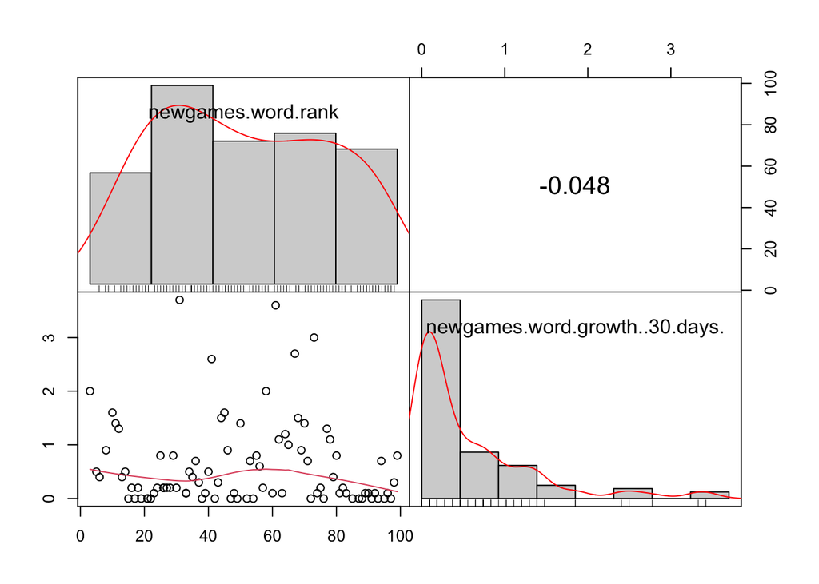

```r
chart.Correlation(data.frame(newgames.word$rank, newgames.word$growth..30.days.))
```

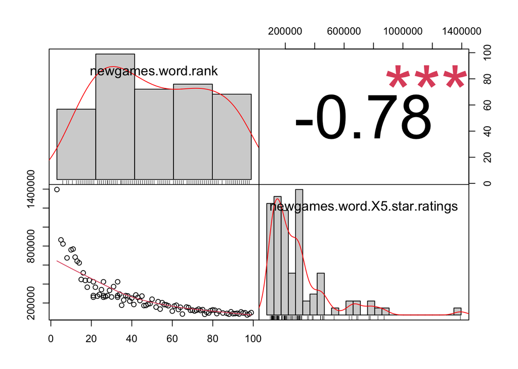

```r
chart.Correlation(data.frame(newgames.word$rank, newgames.word$X5.star.ratings))
```

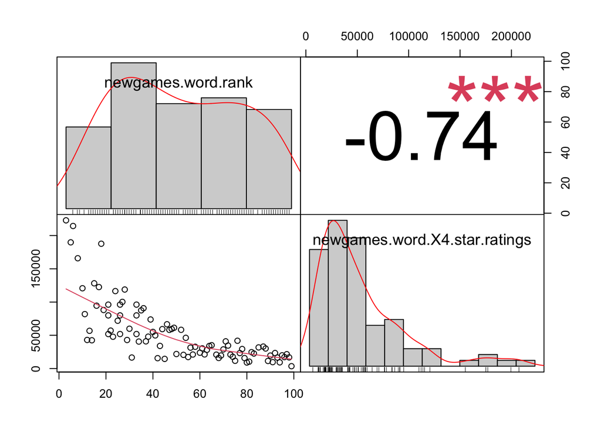

```r
chart.Correlation(data.frame(newgames.word$rank, newgames.word$X4.star.ratings))
```

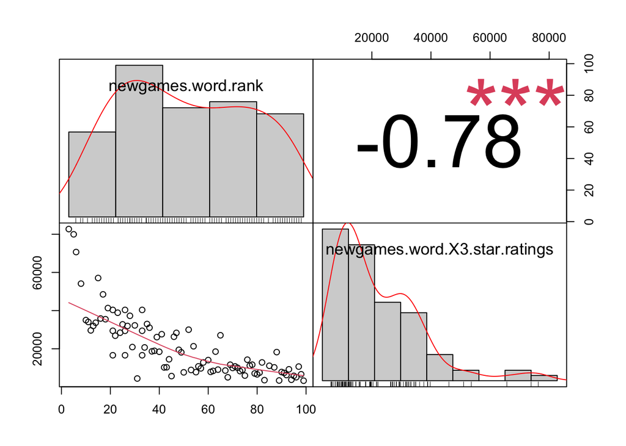

```r
chart.Correlation(data.frame(newgames.word$rank, newgames.word$X3.star.ratings))
```

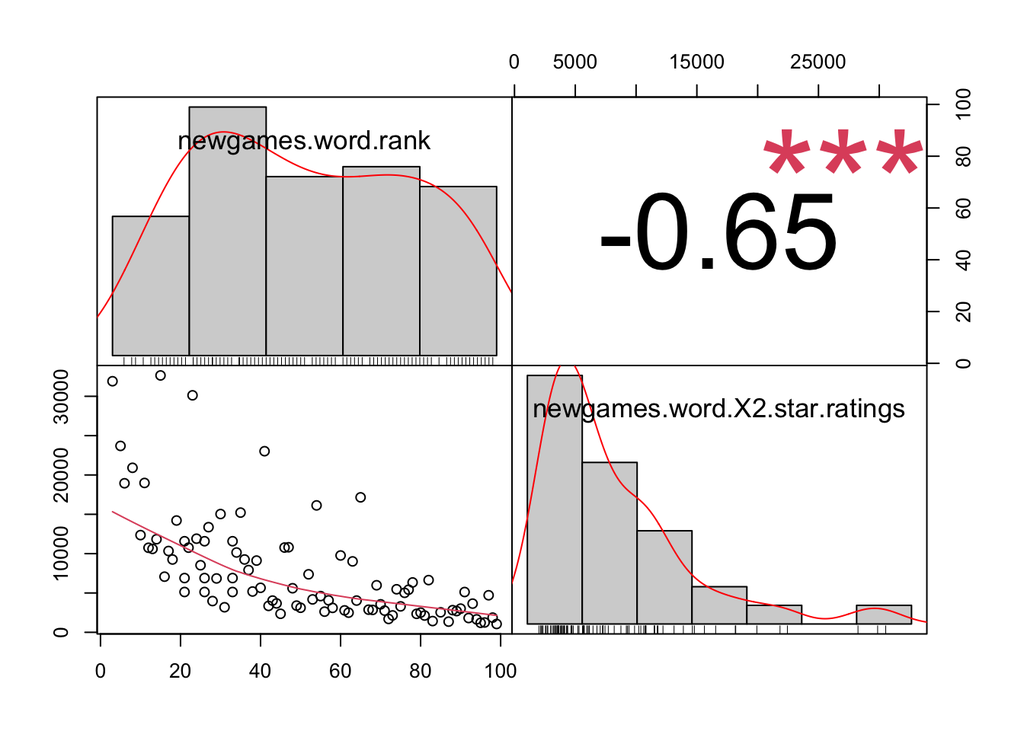

```r
chart.Correlation(data.frame(newgames.word$rank, newgames.word$X2.star.ratings))
```

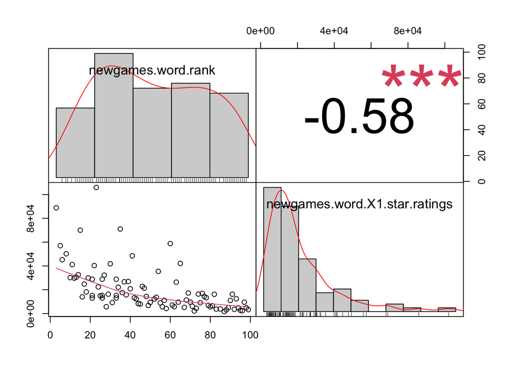

```r
chart.Correlation(data.frame(newgames.word$rank, newgames.word$X1.star.ratings))
```

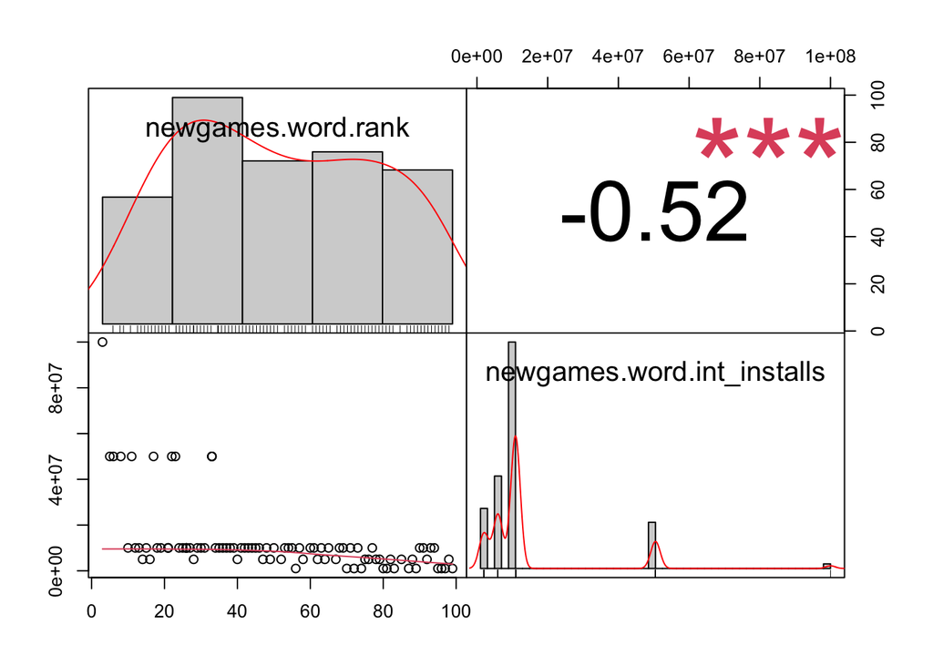

```r
chart.Correlation(data.frame(newgames.word$rank, newgames.word$int_installs))
```

#### 4.3.2 ¿El ranking de los juegos de la categoría GAME WORD es superior en caso de tener unas instalaciones elevadas?.

Continuando con las pruebas estadísticas, ahora vamos a hacer un contraste de hipótesis de dos muestras sobre la media, utilizaremos la **Prueba de T-Studente** (t-test) Una muestra va a contener todos los juegos de la categoría GAME WORD cuyas descargas sean inferiores a 10 millones, y la segunda muestra va a contener los juego de la categoría GAME WORD cuyas descargas sean iguales o superiores a 10 millones:

```r
ranking.ins_low = newgames.ins_low$rank
ranking.ins_high = newgames.ins_high$rank
```

En este caso la hipótesis nula (H0) es que la media de ambas muestras son iguales, y la hipótesis alternativa (H1) la media de los juegos con instalaciones elevadas es mayor que la media de los juegos con instalaciones bajas:

H0: media_inst_elevadas = media_inst_bajas H1: media_inst_elevadas > media_inst_bajas

Para aplicar el test de T-Student necesitamos asumir la normalidad de los datos, en nuestro caso podemos aplicar el Teorema del Límite Central, el cual nos indica que la media de una muestra que sea lo suficientemente grande (mayor de 30 observaciones) sigue una distribución normal. Al poder calcular la media de ambas muestras esto lo cumplimos, solo nos hace falta comprobar que tenemos el número de observaciones mínimas, pero tal y como vemos a continuación esto también se cumple:

```r
cat("El número de observaciones de instalaciones bajas es: ", nrow(newgames.ins_low))
```

```
## El número de observaciones de instalaciones bajas es:  33
```

```r
cat("El número de observaciones de instalaciones altas es: ", nrow(newgames.ins_high))
```

```
## El número de observaciones de instalaciones altas es:  60
```

Una vez asumida la normalidad, hacemos uso de la función t.test que nos devuelve el pvalor para este caso, consideramos un nivel de significancia del 0.05:

```r
t.test(ranking.ins_high, ranking.ins_low, alternative = "greater", var.equal = TRUE)
```

```
##
##  Two Sample t-test
##
## data:  ranking.ins_high and ranking.ins_low
## t = -6.2061, df = 91, p-value = 1
## alternative hypothesis: true difference in means is greater than 0
## 95 percent confidence interval:
##  -39.60803       Inf
## sample estimates:
## mean of x mean of y
##  39.33333  70.57576
```

De la anterior ejecución vemos que el pvalor = 1 y alfa = 0.05, como el pvalor no es menor que la alfa no podemos rechazar la hipótesis nula, es decir, no podemos garantizar que el ranking de un juego cuya categoría es GAME WORD y el número de instalaciones sea elevado tenga un ranking superior que un juego de la misma categoría pero con un número de instalaciones bajo.

#### 4.3.3 Modelo de regresión lineal.

Tal y como se definió en el primer apartado de la práctica, podría ser interesante el predecir qué ranking va a tener nuestro juego dentro de la categoría GAME WORD, esto podría sernos de utilidad para saber si nuestro juego va a tener éxisto o no dependiendo de las características que lo definen, como por ejemplo: el rating, el número de instalaciones…

Como a priori no sabemos qué modelo se va a comportar mejor para nuestros datos, vamos a crear diferentes modelos de regresión lineal, posteriormente comprobaremos qué modelo se comporta mejor y usaremos éste para hacer una predicción.

Para evaluar qué modelo es el mejor nos fijaremos en la medida estadística R2, ésta nos indica cómo de cerca están los datos respecto a la recta de regresión, o dicho en otras palabras cuánta variabilidad es explicado por el modelo, por lo que a mayor R2 mejor es el modelo.

Para definir un modelo de regresión lineal tenemos que determinar cuál es la variable objetivo, en nuestro caso el campo “rank” y las variables independientes.

Para el primer modelo vamos a usar como variable independientes solamente el crecimiento en 30 días y el número de instalaciones:

```r
m1_rlm = lm(rank ~ growth..30.days. + int_installs, data = newgames.word)
```

En el segundo modelo vamos a continuar con el número de instalaciones, pero añadimos los ratings de 5, 3 y 1 estrellas:

```r
m2_rlm = lm(rank ~ X5.star.ratings + X3.star.ratings + X1.star.ratings + int_installs,
            data = newgames.word)
```

El último modelo es similar al anterior, pero añadiendo los ratings de 4 y 2 estrellas:

```r
m3_rlm = lm(rank ~ X5.star.ratings + X4.star.ratings + X3.star.ratings + X2.star.ratings +
            X1.star.ratings + int_installs, data = newgames.word)
```

Una vez que hemos creado todos los modelos obtenemos el coeficiente de determinación (R2) para cada uno de ellos:

```r
vec_modelos = c("Modelo 1", "Modelo 2", "Modelo 3")
vec_R2 = c(summary(m1_rlm)$r.squared, summary(m2_rlm)$r.squared,
           summary(m3_rlm)$r.squared)
df_R2 = data.frame(
  vec_modelos,
  vec_R2
)
names(df_R2) = c("Modelos", "R2")

head(df_R2)
```

```
##    Modelos        R2
## 1 Modelo 1 0.2743632
## 2 Modelo 2 0.6973041
## 3 Modelo 3 0.7014700
```

Observamos que el modelo que mejor se comporta con nuestros datos es el tercero, es decir, aquel en el que incluimos todas las variables significativas que están correlacionadas con la variable objetivo, en nuestro caso con rank.

Finalmente, vamos a predecir qué posición dentro del ranking tendría un juego creado para la categoría GAME WORD:

```r
head(newgames.word)
```

```
##      rank                                             title growth..30.days.
## 1627    3 Words of Wonders: Crossword to Connect Vocabulary              2.0
## 1629    5                                 4 Fotos 1 Palabra              0.5
## 1630    6                                     4 Pics 1 Word              0.4
## 1632    8                      CodyCross: Crossword Puzzles              0.9
## 1634   10                                      Word Connect              1.6
## 1635   11                                        Wordscapes              1.4
##      price X5.star.ratings X4.star.ratings X3.star.ratings X2.star.ratings
## 1627     0         1395622          222919           82725           31915
## 1629     0          865192          189818           79976           23692
## 1630     0          822765          214414           70684           18945
## 1632     0          675125          165913           54134           20912
## 1634     0          760211          120763           35012           12357
## 1635     0          768395           81889           34033           18984
##      X1.star.ratings category_num2 int_installs
## 1627           88867            17        1e+08
## 1629           57033            17        5e+07
## 1630           45250            17        5e+07
## 1632           50217            17        5e+07
## 1634           30173            17        1e+07
## 1635           41168            17        5e+07
```

```r
# Creamos el dataframe con los valores para predecir
df_game = data.frame(
  X5.star.ratings = 945761,
  X4.star.ratings = 30156,
  X3.star.ratings = 5123,
  X2.star.ratings = 439,
  X1.star.ratings = 27899,
  int_installs = 5000000
)

# Predecimos el rank que tendría nuestro juego
cat("El rank que tendría nuestro juego sería el: ", round(predict(m3_rlm, df_game)))
```

```
## El rank que tendría nuestro juego sería el:  8
```

# 5. Representación de los resultados a partir de tablas y gráficas.

Una vez que hemos realizado la limpieza y el análisis de datos, el cual no ha permitido obtener información a partir de los mismos, vamos a continuar con el análisis pero de una forma visual, es decir, a partir de gráficos, de los cuales extraeremos las conclusiones y las enlazaremos con el apartado anterior.

Pero antes de continuar, para facilitar la representación de la información, vamos a discretizar las variables significativas según el análisis hecho anteriormente, es decir, la variable rank, los ratings e int_installs:

```r
newgames_discretizado = newgames.word

# Discretización de rank
newgames_discretizado["d-rank"] = ordered(cut(newgames_discretizado[["rank"]],
                      breaks = c(0,26,74,100), labels = c("Alto", "Medio", "Bajo")))

# Discretización de X5.star.ratings
newgames_discretizado["d-X5.star.ratings"] = ordered(cut(newgames_discretizado[["X5.star.ratings"]],
                                             breaks = c(0,121285,284850,1395623),
                                             labels = c("Bajo", "Medio", "Alto")))

# Discretización de X4.star.ratings
newgames_discretizado["d-X4.star.ratings"] = ordered(cut(newgames_discretizado[["X4.star.ratings"]],
                                             breaks = c(0,21082,71891,222920),
                                             labels = c("Bajo", "Medio", "Alto")))

# Discretización de X3.star.ratings
newgames_discretizado["d-X3.star.ratings"] = ordered(cut(newgames_discretizado[["X3.star.ratings"]],
                                             breaks = c(0,8884,29994,82726),
                                             labels = c("Bajo", "Medio", "Alto")))

# Discretización de X2.star.ratings
newgames_discretizado["d-X2.star.ratings"] = ordered(cut(newgames_discretizado[["X2.star.ratings"]],
                                             breaks = c(0,3011,10747,32652),
                                             labels = c("Bajo", "Medio", "Alto")))

# Discretización de X1.star.ratings
newgames_discretizado["d-X1.star.ratings"] = ordered(cut(newgames_discretizado[["X1.star.ratings"]],
                                             breaks = c(0,7122,26938,105952),
                                             labels = c("Bajo", "Medio", "Alto")))

# Discretización de int_installs
newgames_discretizado["d-int_installs"] = ordered(cut(newgames_discretizado[["int_installs"]],
                                          breaks = c(0, 9999999, 100000000),
                                          labels = c("Bajo","Alto")))
```

Vemos el cómo se han creado dichas variables:

```r
str(newgames_discretizado)
```

```
## 'data.frame':    93 obs. of  18 variables:
##  $ rank             : int  3 5 6 8 10 11 12 13 14 15 ...
##  $ title            : chr  "Words of Wonders: Crossword to Connect Vocabulary" "4 Fotos 1 Palabra" "4 Pics 1 Word" "CodyCross: Crossword Puzzles" ...
##  $ growth..30.days. : num  2 0.5 0.4 0.9 1.6 1.4 1.3 0.4 0.5 0 ...
##  $ price            : num  0 0 0 0 0 0 0 0 0 0 ...
##  $ X5.star.ratings  : int  1395622 865192 822765 675125 760211 768395 683334 640995 622699 448237 ...
##  $ X4.star.ratings  : int  222919 189818 214414 165913 120763 81889 43008 56751 42507 128193 ...
##  $ X3.star.ratings  : int  82725 79976 70684 54134 35012 34033 29632 31968 33642 57079 ...
##  $ X2.star.ratings  : int  31915 23692 18945 20912 12357 18984 10747 10602 11833 32651 ...
##  $ X1.star.ratings  : int  88867 57033 45250 50217 30173 41168 29742 30549 32642 70036 ...
##  $ category_num2    : int  17 17 17 17 17 17 17 17 17 17 ...
##  $ int_installs     : num  1e+08 5e+07 5e+07 5e+07 1e+07 5e+07 1e+07 1e+07 5e+06 1e+07 ...
##  $ d-rank           : Ord.factor w/ 3 levels "Alto"<"Medio"<..: 1 1 1 1 1 1 1 1 1 1 ...
##  $ d-X5.star.ratings: Ord.factor w/ 3 levels "Bajo"<"Medio"<..: 3 3 3 3 3 3 3 3 3 3 ...
##  $ d-X4.star.ratings: Ord.factor w/ 3 levels "Bajo"<"Medio"<..: 3 3 3 3 3 3 2 2 2 3 ...
##  $ d-X3.star.ratings: Ord.factor w/ 3 levels "Bajo"<"Medio"<..: 3 3 3 3 3 3 2 3 3 3 ...
##  $ d-X2.star.ratings: Ord.factor w/ 3 levels "Bajo"<"Medio"<..: 3 3 3 3 3 3 2 2 3 3 ...
##  $ d-X1.star.ratings: Ord.factor w/ 3 levels "Bajo"<"Medio"<..: 3 3 3 3 3 3 3 3 3 3 ...
##  $ d-int_installs   : Ord.factor w/ 2 levels "Bajo"<"Alto": 2 2 2 2 2 2 2 2 1 2 ...
```

```r
head(newgames_discretizado)
```

```
##      rank                                             title growth..30.days.
## 1627    3 Words of Wonders: Crossword to Connect Vocabulary              2.0
## 1629    5                                 4 Fotos 1 Palabra              0.5
## 1630    6                                     4 Pics 1 Word              0.4
## 1632    8                      CodyCross: Crossword Puzzles              0.9
## 1634   10                                      Word Connect              1.6
## 1635   11                                        Wordscapes              1.4
##      price X5.star.ratings X4.star.ratings X3.star.ratings X2.star.ratings
## 1627     0         1395622          222919           82725           31915
## 1629     0          865192          189818           79976           23692
## 1630     0          822765          214414           70684           18945
## 1632     0          675125          165913           54134           20912
## 1634     0          760211          120763           35012           12357
## 1635     0          768395           81889           34033           18984
##      X1.star.ratings category_num2 int_installs d-rank d-X5.star.ratings
```

[output cut: 20 more lines]

Una vez que ya tenemos las variables discretizadas vamos a realizar la representación del análisis de estos datos. Lo primero que vamos a analizar es el ranking respecto al número de instalaciones, este fue el objeto de estudio del contraste de hipótesis:

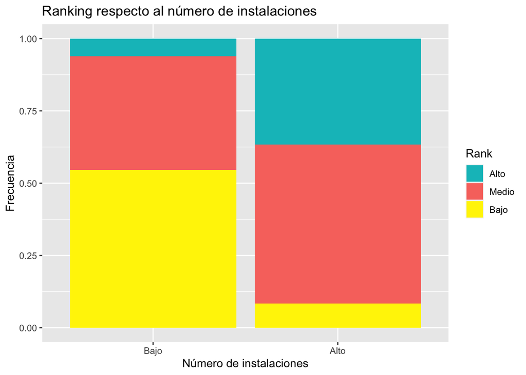

```r
ggplot(data = newgames_discretizado, aes(x=`d-int_installs`,fill=`d-rank`)) +
  geom_bar(position = "fill") +
  xlab("Número de instalaciones") +
  ylab("Frecuencia") +
  scale_fill_manual(name = "Rank", values=c("#00bfc4","#f8766d", "#fff300")) +
  ggtitle("Ranking respecto al número de instalaciones")
```

Del anterior gráfico vemos que a mayor número de instalaciones como es lógico un mayor ranking tenemos, pero tal y como vimos en el contraste de hipótesis esto no significa que siempre sea así, por lo que no podemos garantizar que si un juego tiene muchas descargas vaya a tener un ranking alto.

El siguiente aspecto a analizar es el número de estrellas que tiene cada juego y si esto significa un mayor ranking.

Por lo que primero vamos a analizar el número de calificaciones de 5 estrellas:

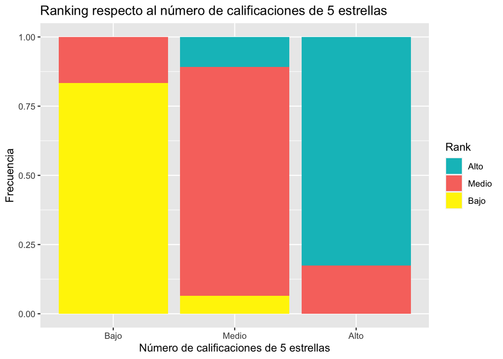

```r
ggplot(data = newgames_discretizado, aes(x=`d-X5.star.ratings`,fill=`d-rank`)) +
  geom_bar(position = "fill") +
  xlab("Número de calificaciones de 5 estrellas") +
  ylab("Frecuencia") +
  scale_fill_manual(name = "Rank", values=c("#00bfc4","#f8766d", "#fff300")) +
  ggtitle("Ranking respecto al número de calificaciones de 5 estrellas")
```

Como podemos apreciar, aquellos juego que tienen un elevado número de calificaciones significa que el juego tiene un ranking mayor, por contra si el número de calificaciones es bajo es más probable tener un juego con un ranking bajo o medio.

Realizamos el mismo análisis pero para las calificaciones de 4 estrellas:

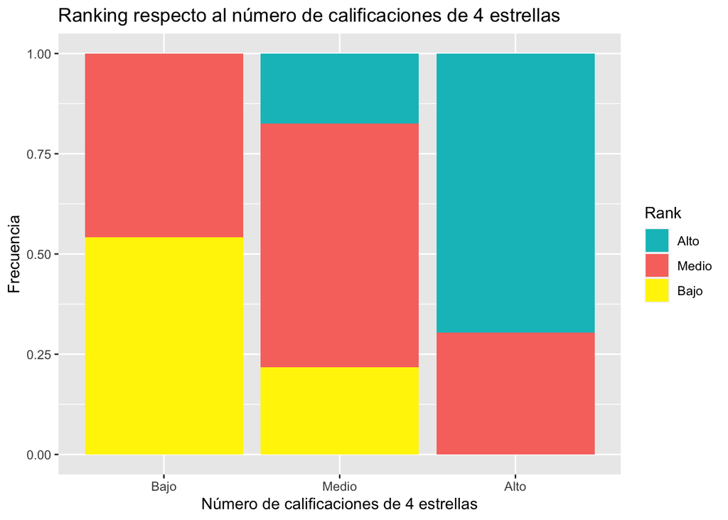

```r
ggplot(data = newgames_discretizado, aes(x=`d-X4.star.ratings`,fill=`d-rank`)) +
  geom_bar(position = "fill") +
  xlab("Número de calificaciones de 4 estrellas") +
  ylab("Frecuencia") +
  scale_fill_manual(name = "Rank", values=c("#00bfc4","#f8766d", "#fff300")) +
  ggtitle("Ranking respecto al número de calificaciones de 4 estrellas")
```

Al igual que sucedía antes, cuanto más elevado sea el número de calificaciones más probable que el juego tenga un ranking alto o medio, sin embargo si tenemos pocas calificaciones de cuatro estrellas la posición en el ranking va a ser peor.

Analizamos las calificaciones de 3 estrellas:

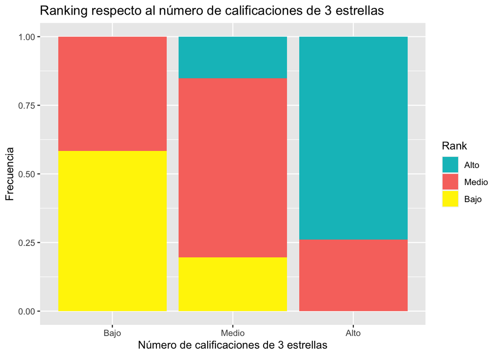

```r
ggplot(data = newgames_discretizado, aes(x=`d-X3.star.ratings`,fill=`d-rank`)) +
  geom_bar(position = "fill") +
  xlab("Número de calificaciones de 3 estrellas") +
  ylab("Frecuencia") +
  scale_fill_manual(name = "Rank", values=c("#00bfc4","#f8766d", "#fff300")) +
  ggtitle("Ranking respecto al número de calificaciones de 3 estrellas")
```

Siguiendo con la tónica de los casos anterior, a mayor número de calificaciones de 3 estrellas mejor posición en el ranking y a menor número peor posición.

Seguimos analizando las calificaciones de 2 estrellas:

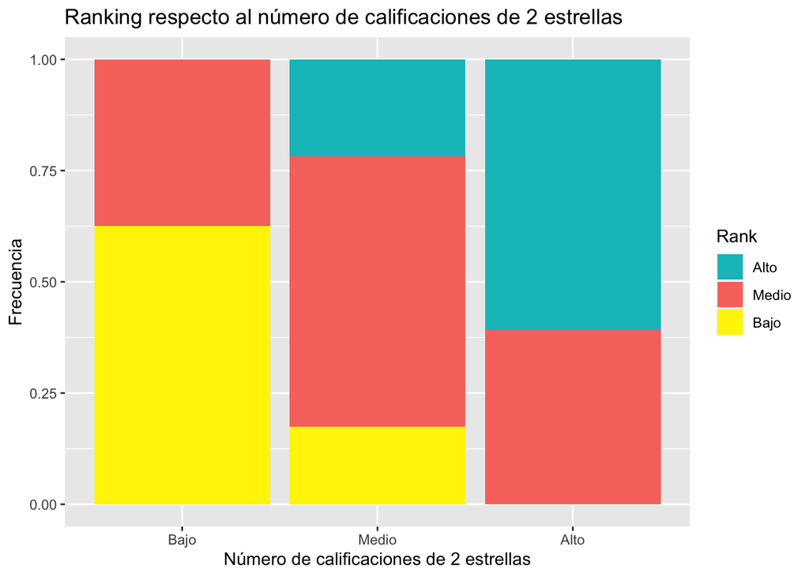

```r
ggplot(data = newgames_discretizado, aes(x=`d-X2.star.ratings`,fill=`d-rank`)) +
  geom_bar(position = "fill") +
  xlab("Número de calificaciones de 2 estrellas") +
  ylab("Frecuencia") +
  scale_fill_manual(name = "Rank", values=c("#00bfc4","#f8766d", "#fff300")) +
  ggtitle("Ranking respecto al número de calificaciones de 2 estrellas")
```

Aunque lo lógico sería que a medida que vamos reduciendo las estrellas de un juego su ranking sea peor, vemos que esto no es del todo cierto, ya que en este caso los juegos que siguen teniendo un elevado número de calificaciones de 2 estrellas siguen con un ranking elevado.

Esto solo tiene una explicación, y es que lo juegos mejor posicionados en el ranking tienen un mayor número de calificaciones en todos los niveles, es decir, tanto en 5 como 4, 3, 2 o una estrella. Por lo tanto, al hacer el análisis del ranking para cada nivel de calificación vemos que los juegos con una alta posición siempre tienen el mayor número de calificaciones (aunque en este caso una calificación de 2 estrellas sea algo negativo), por otro lado, esto no significa que los juegos con una posición baja en el ranking tengan bajo cada uno de los niveles de calificación, seguramente el número de calificaciones para cada nivel sea menor que los juego mejor posicionados, pero en comparativa éstos tienen peores calificaciones.

Por último, analizamos el número de calificaciones de 1 estrellas:

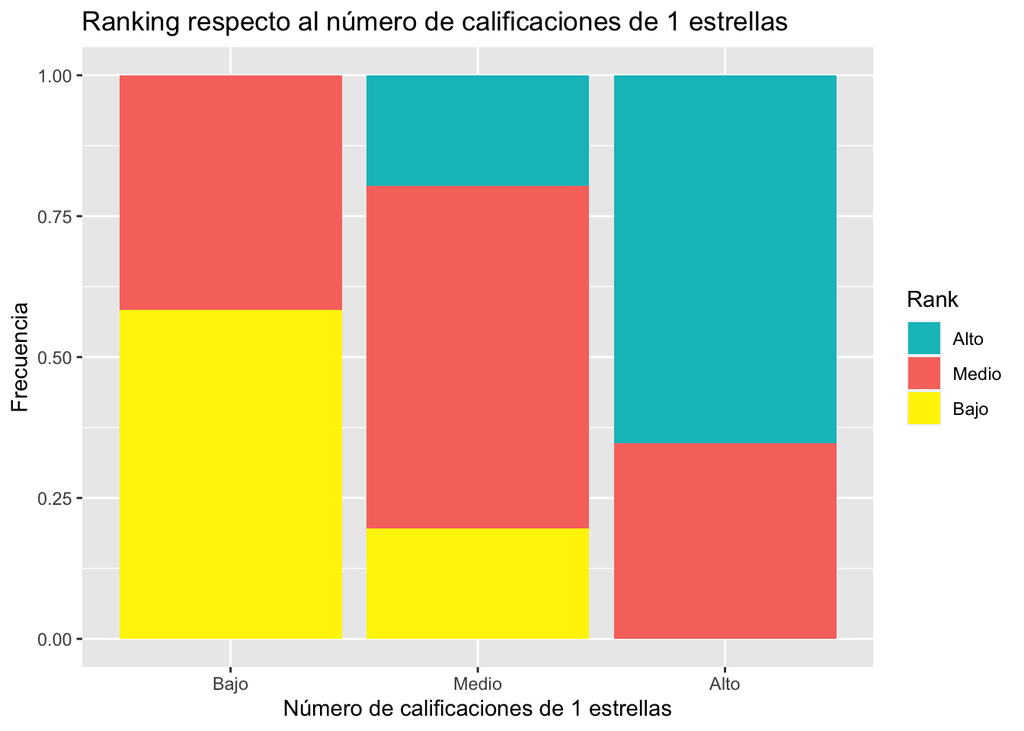

```r
ggplot(data = newgames_discretizado, aes(x=`d-X1.star.ratings`,fill=`d-rank`)) +
  geom_bar(position = "fill") +
  xlab("Número de calificaciones de 1 estrellas") +
  ylab("Frecuencia") +
  scale_fill_manual(name = "Rank", values=c("#00bfc4","#f8766d", "#fff300")) +
  ggtitle("Ranking respecto al número de calificaciones de 1 estrellas")
```

Al igual que sucedía en el caso anterior, los juegos mejor posicionados en el ranking tienen un mayor número de calificaciones de 1 estrella, pero esto se debe a que tienen un mayor número de calificaciones en todos los niveles, pero en comparativa los juegos con peor ranking tienen peores valoraciones en todos los niveles.

# 6. Resolución del problema.

### A partir de los resultados obtenidos, ¿cuáles son las conclusiones? ¿Los resultados permiten responder al problema?

### 6.1 A partir de los resultados obtenidos, ¿cuáles son las conclusiones? ¿Los resultados permiten responder al problema?

El objetivo de esta práctica más que resolver un problema a sido dar respuesta ha una serie de preguntas, la principal de ellas, ¿De qué depende que un juego tenga un ranking mayor o menor, es decir, de que factores depende el éxito que pueda tener? ¿El ranking de los juegos de una categoría determinada es superior en caso de tener unas instalaciones elevadas?

A lo largo de práctica hemos dado respuestas a estas preguntas, a demás de desarrollar un modelo de regresión lineal que nos permite predecir cual será el puesto en el ranking de un video juego determinado, es decir, el éxito del juego.

Del análisis realizado podemos concluir, que las variables que más influyen sobre el puesto que ocupa un video juego en el ranking son el número de estrellas obtenidas, a mayor número de estrellas más alto es el puesto del video juego en el ranking, esto lo hemos comprobado estudiando la correlación de las variables cuantitativas con el ranking. Por otro lado, En el análisis gráfico hemos podido ver que hay categorías de juegos que a mayor número de instalaciones mayor es su puesto en el ranking pero está afirmación no se puede extender a todas las categorías.

Por último, hemos desarrollado un modelo de regresión lineal con las variables ranking, calificación en estrellas (X1, X2, X3, X4, X5) y número de instalaciones, que tras analizar distinto modelo, este es el que ha obtenido un coeficiente de determinación (R cuadrado) mayor, por lo que se considera más idóneo. Este modelo nos ha permitido hacer la predicción de la posición de una categoría determinada en el ranking. Esto se puede trasladar a cualquier categoría de nuestro dataset. Esto es de gran utilidad en caso de querer invertir en un video juego o querer publicitarnos en el mismo, ya que la mayor parte de los video juegos son gratuitos y su ingresos provienen de la publicidad, en base a nuestro análisis podríamos elegir un video juego que tendrá éxito, lo que nos garantiza una mejor inversión e impacto de la publicidad.

# 7. Código:

Para el desarrollo de la práctica el lenguaje de programación elegido ha sido R.

El dataset se ha extraido del siguiente enlace:

https://www.kaggle.com/dhruvildave/top-play-store-games?select=android-games.csv

Por último se ha organizado en el proyecto de la siguiente manera:

- **code/Práctica 2 Limpieza de datos.Rmd** : Archivo con el código en R que se ha utilizado para cada uno de los apartados de la práctica.
- **code/Práctica 2 Limpieza de datos.pdf** : Archivo en pdf donde se muestra el contenido de la práctica.
- **code/Práctica 2 Limpieza de datos.html** : Archivo en html donde se muestra el contenido de la práctica.
- **data/android-games.csv** : Archivo original con los datos sobres los que hemos hecho el análisis.
- **data/newgames.csv** : Archivo con los datos tras hacer la limpieza de datos.

Para el desarrollo de la práctica se ha seguido la siguiente metodología desarrollada en cuatro etapas:

**Fase 1**: Se realiza la comprensión y contextualización de los datos a los cuáles se les va a realizar el análisis. Con ellos identificamos si existen problemas de calidad y se identifican los datos que necesitan ser limpiados.

**Fase 2**: Se definen los métodos a realizar solventar los problemas identificados y se realiza el proceso de limpieza de datos.

**Fase 3**: Se realiza el análisis por medio de métodos estadísticos descriptivos e inferenciales.

**Fase 4**: Se analizan los resultados obtenidos del proceso anterior, formulando las conclusiones que se desprenden de los resultados.

# 8.Tabla de contribuciones al trabajo:

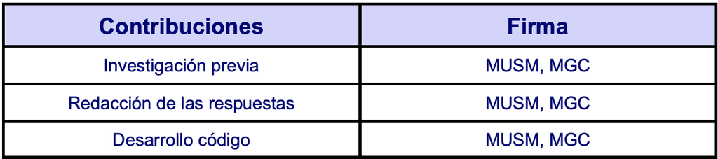

```r
knitr::include_graphics("../code/Tabla.png")
```

MUSM: Mario Ubierna San Mamés.

MGC: Moreyba García Cedrés.

# 9.Referencias:

1. Calvo M, Subirats L, Pérez D (2019). Introducción a la limpieza y análisis de los datos. Editorial UOC.
2. Jason W. Osborne (2010). Data Cleaning Basics: Best Practices in Dealing with Extreme Scores. Newborn and Infant Nursing Reviews; 10 (1): pp. 1527-3369.
3. Peter Dalgaard (2008). Introductory statistics with R. Springer Science & Business Media.
4. Gibergans Baguena, Josep. 2009. «Contraste de dos muestras». En Estadística, editado por Josep Gibergans Baguena, Angel J. Gil Estallo, y Carles Rovira Escofet. Barcelona: FUOC.
5. Gil Estallo, Angel J. 2009. «Intervalos de confianza». En Estadística, editado por Angel J. Gil Estallo J. Gibergans Baguena y Carles Rovira Escofet. Barcelona: FUOC.
6. Rovira, Carles. 2009. «Contraste de hipoótesis». En Estadística, editado por J. Gibergans Baguena, Angel J. Gil Estallo, y Carles Rovira Escofet. Barcelona: FUOC.